# State Politics & Energy Usage

Nathan Bush

Advanced Data Analytics

## Introduction

1. **Potential Topics**
   - Fish populations in the Salmon river
   - National Park visitation and Social Media
2. **Motivation**
   - Curious about state politics & how it effects decision making
   - Energy is a good metric to measure this
   - Interesting independently
3. **Hypothesis**
   - Conservative states use less energy than is optimal

## Why is this important?

- Do state politics interfere with decision making?
- Are states acting in their own best interest?
- Understand these dynamics to best inform policy

## Data

**Energy usage statistics by state** - US Energy Information Administration

**2000-2020 presidential election data** -MIT Election and Data Science Lab & the Harvard Dataverse

**2022 State Governors** -Webscraped from Wikipedia —

# Data Cleaning Process

**Energy Use Data** - This dataset needed the most work - Removed rows containing non-data entries - Removed variables unnecessary to my analysis - Applied transformations to key variables - (* = 0 | –, NM = N/A)

**Election Data** - Clean Dataset…tricky variable creation - Summed votes for candidates within states to determine victor - Dummy variable = 1 if a state voted for Trump

**Governor Data** - Webscraped Wikipedia Table - Easy to clean and process - Dummy variable = 1 if a state has a republican governor

**Question 1**

Are there discernible differences between renewable energy use based on political affiliation between states?

Three Categories -Red -Blue -Purple

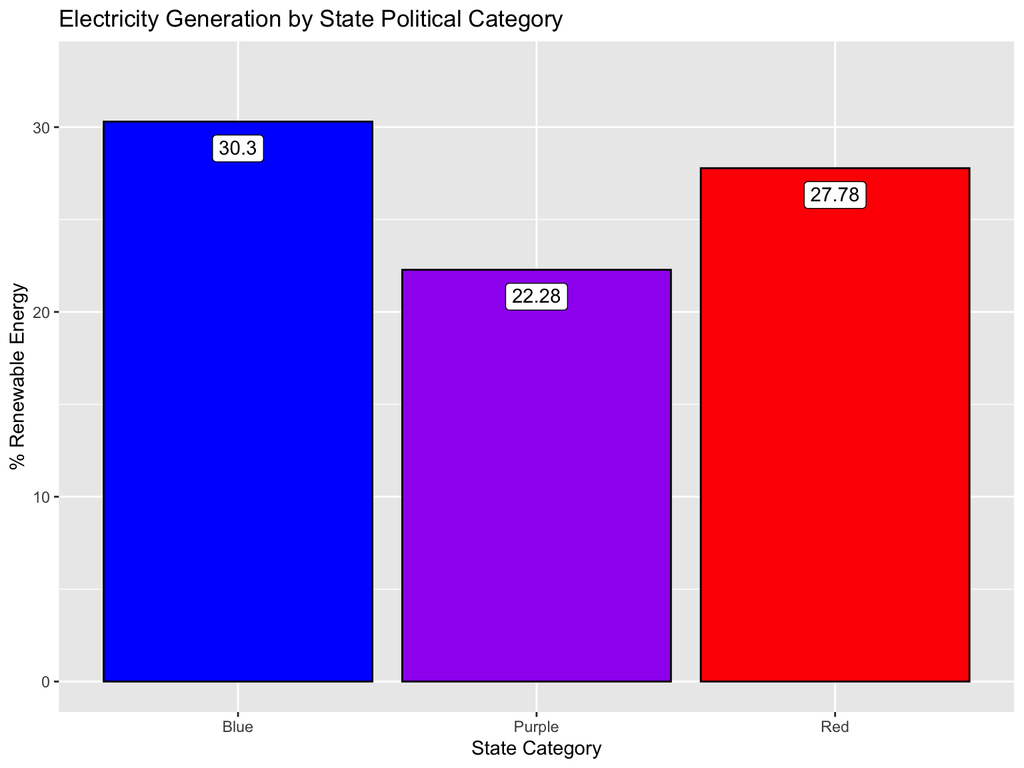